# ESM 204 Assignment 4

Madeline Oliver

5/19/2020

Equations: temp = temperature in year t econ = the fraction of economic activity that is retained in a year if the temp is “temp” consumption = total consumption at time t utility = society’s utility from consumption Ramsey rule: o = pure rate of time preference g = growth rate of income over time n = elasticity of marginal utility of consumption with respect to income (how much more does a poor person value a dollar compared to a rich person?)

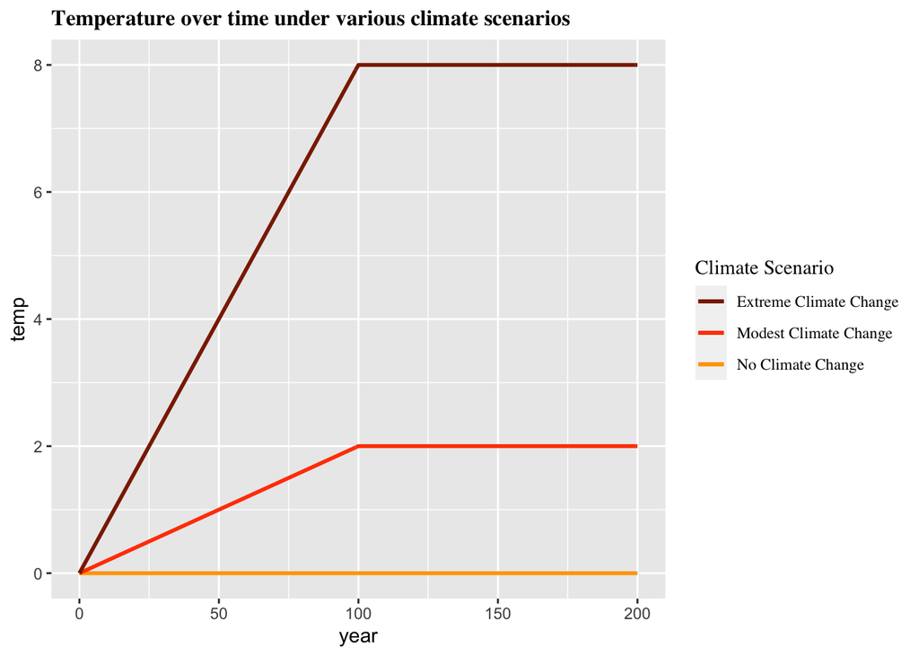

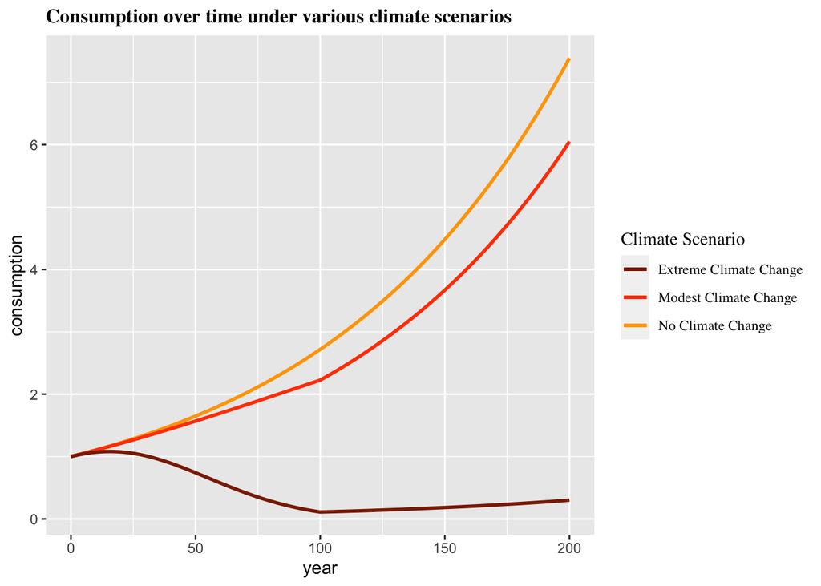

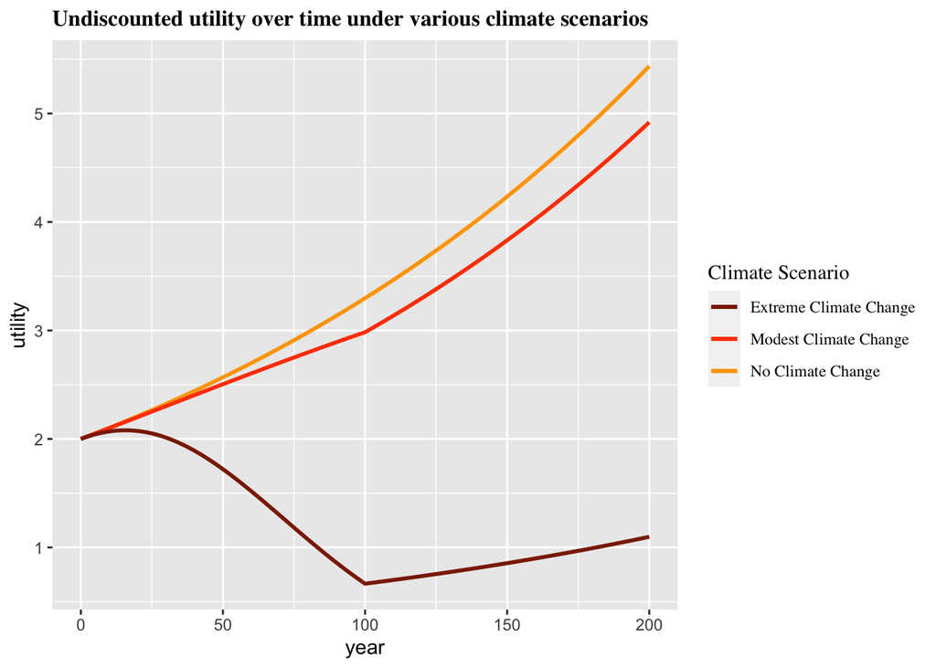

Formula for present value: net utility today = SUM[utility at year t / (1+discount_rate)^t] across all years

Part 2.B.

10% increase in $\delta$

The delta elasticity of utility is -5.4928111 The pct change in L is -0.5492811

10% increase in $\eta$

The eta elasticity of utility is -0.8591453 The pct change in L is -0.0859145

10% increase in g

The gamma elasticity of utility is 535.4779045 The pct change in L is 53.5477905

10% increase in $\beta$

The beta elasticity of utility is 1.2589729 The pct change in L is 0.1258973

10% increase in T_bau

The temperature elasticity of utility is 0.6126784 The pct change in L is 0.0612678

2.c. $\theta$-

When we are certain that under business as usual, T = 4.4, society is willing to give up 0.3943595 of their consumption every year for the next 200 years in order to completely prevent climate change.

Under uncertainty over T, society is willing to give up 0.3778873 of their consumption every year for the next 200 years in order to completely prevent climate change.